# Introduction to Forecasting in R

## Setup

```r
library(forecast)
library(ggplot2)

data = read.csv("portal_timeseries.csv", stringsAsFactors = FALSE)
data$date = as.Date(data$date, format = "%m/%d/%Y")
head(data)
```

```
##   X     NDVI rain  rodents       date
## 1 1 0.181375 39.3 445.8643 1992-03-15
## 2 2 0.243400 29.4 491.1766 1992-04-15
## 3 3 0.218500 20.4 384.7876 1992-05-15
## 4 4 0.217700  0.0 439.2565 1992-06-15
## 5 5 0.207800 82.6 391.8683 1992-07-15
## 6 6 0.220150 19.1 430.8875 1992-08-15
```

```r
NDVI_ts = ts(data$NDVI, start = c(1992, 3), end = c(2014, 11), frequency = 12)
```

## Steps in forecasting

1. Problem definition
2. Gather information
3. Exploratory analysis
4. Choosing and fitting models
5. Make forecasts
6. Evaluate forecasts

## Exploratory analysis

- Process we went through over the last few weeks
- Look at the data structure

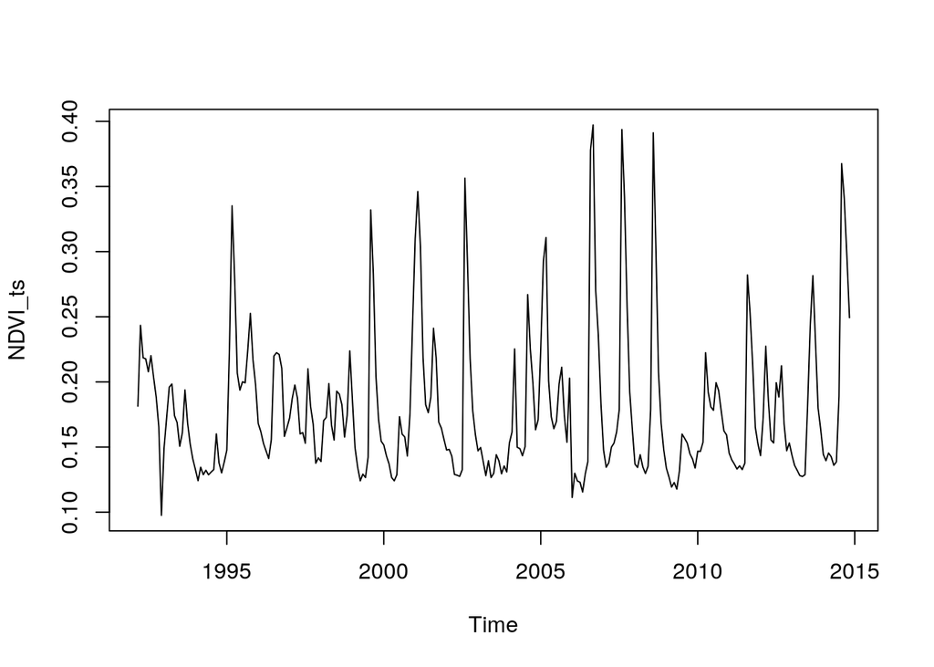

```r
plot(NDVI_ts)
```

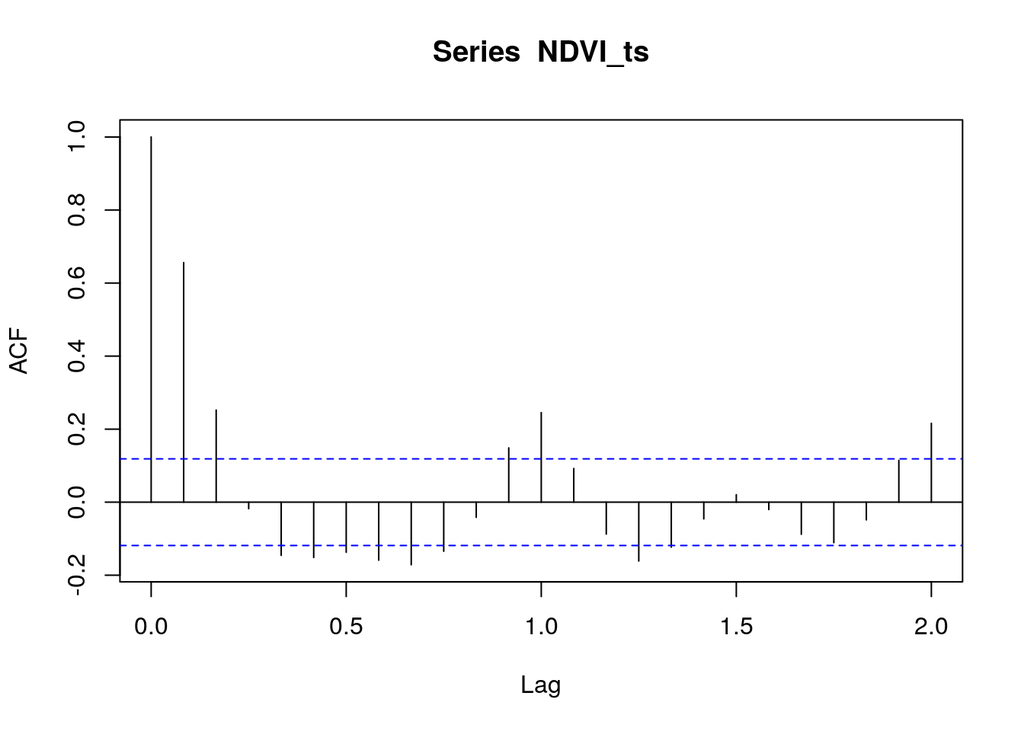

```r
acf(NDVI_ts)
```

## Choose and fit models

- Simples model was white noise or the “naive” model:

  > y_t = c + e_t, where e_t ~ N(0, sigma)
- Fit this model using `Arima()`

```r
avg_model = Arima(NDVI_ts, c(0, 0, 0))
str(avg_model)
```

```
## List of 18
##  $ coef     : Named num 0.179
##   ..- attr(*, "names")= chr "intercept"
##  $ sigma2   : num 0.00315
##  $ var.coef : num [1, 1] 1.15e-05
##   ..- attr(*, "dimnames")=List of 2
##   .. ..$ : chr "intercept"
##   .. ..$ : chr "intercept"
##  $ mask     : logi TRUE
##  $ loglik   : num 400
##  $ aic      : num -795
##  $ arma     : int [1:7] 0 0 0 0 12 0 0
##  $ residuals: Time-Series [1:273] from 1992 to 2015: 0.00229 0.06431 0.03941 0.03861 0.02871 ...
##  $ call     : language Arima(y = NDVI_ts, order = c(0, 0, 0))
##  $ series   : chr "NDVI_ts"
##  $ code     : int 0
##  $ n.cond   : int 0
##  $ nobs     : int 273
##  $ model    :List of 10
##   ..$ phi  : num(0)
##   ..$ theta: num(0)
##   ..$ Delta: num(0)
##   ..$ Z    : num 1
##   ..$ a    : num 0.0702
##   ..$ P    : num [1, 1] 0
##   ..$ T    : num [1, 1] 0
##   ..$ V    : num [1, 1] 1
##   ..$ h    : num 0
##   ..$ Pn   : num [1, 1] 1
##  $ aicc     : num -795
##  $ bic      : num -788
##  $ x        : Time-Series [1:273] from 1992 to 2015: 0.181 0.243 0.218 0.218 0.208 ...
##  $ fitted   : Time-Series [1:273] from 1992 to 2015: 0.179 0.179 0.179 0.179 0.179 ...
##  - attr(*, "class")= chr [1:3] "forecast_ARIMA" "ARIMA" "Arima"
```

## Make forecasts

- To make forecasts from a model we ask what the model would predict at the time-step
- For the average model we just need to know what c is, which is just the mean(NDVI_ts)

```r
avg_forecast = forecast(avg_model)
str(avg_forecast)
```

```
## List of 10
##  $ method   : chr "ARIMA(0,0,0) with non-zero mean"
##  $ model    :List of 18
##   ..$ coef     : Named num 0.179
##   .. ..- attr(*, "names")= chr "intercept"
##   ..$ sigma2   : num 0.00315
##   ..$ var.coef : num [1, 1] 1.15e-05
##   .. ..- attr(*, "dimnames")=List of 2
##   .. .. ..$ : chr "intercept"
##   .. .. ..$ : chr "intercept"
##   ..$ mask     : logi TRUE
##   ..$ loglik   : num 400
##   ..$ aic      : num -795
##   ..$ arma     : int [1:7] 0 0 0 0 12 0 0
##   ..$ residuals: Time-Series [1:273] from 1992 to 2015: 0.00229 0.06431 0.03941 0.03861 0.02871 ...
##   ..$ call     : language Arima(y = NDVI_ts, order = c(0, 0, 0))
##   ..$ series   : chr "NDVI_ts"
##   ..$ code     : int 0
##   ..$ n.cond   : int 0
##   ..$ nobs     : int 273
##   ..$ model    :List of 10
##   .. ..$ phi  : num(0)
##   .. ..$ theta: num(0)
##   .. ..$ Delta: num(0)
##   .. ..$ Z    : num 1
##   .. ..$ a    : num 0.0702
##   .. ..$ P    : num [1, 1] 0
##   .. ..$ T    : num [1, 1] 0
##   .. ..$ V    : num [1, 1] 1
##   .. ..$ h    : num 0
##   .. ..$ Pn   : num [1, 1] 1
##   ..$ aicc     : num -795
##   ..$ bic      : num -788
##   ..$ x        : Time-Series [1:273] from 1992 to 2015: 0.181 0.243 0.218 0.218 0.208 ...
##   ..$ fitted   : Time-Series [1:273] from 1992 to 2015: 0.179 0.179 0.179 0.179 0.179 ...
##   ..- attr(*, "class")= chr [1:3] "forecast_ARIMA" "ARIMA" "Arima"
##  $ level    : num [1:2] 80 95
##  $ mean     : Time-Series [1:24] from 2015 to 2017: 0.179 0.179 0.179 0.179 0.179 ...
##  $ lower    : Time-Series [1:24, 1:2] from 2015 to 2017: 0.107 0.107 0.107 0.107 0.107 ...
##   ..- attr(*, "dimnames")=List of 2
##   .. ..$ : NULL
##   .. ..$ : chr [1:2] "80%" "95%"
##  $ upper    : Time-Series [1:24, 1:2] from 2015 to 2017: 0.251 0.251 0.251 0.251 0.251 ...
##   ..- attr(*, "dimnames")=List of 2
##   .. ..$ : NULL
##   .. ..$ : chr [1:2] "80%" "95%"
##  $ x        : Time-Series [1:273] from 1992 to 2015: 0.181 0.243 0.218 0.218 0.208 ...
##  $ series   : chr "NDVI_ts"
##  $ fitted   : Time-Series [1:273] from 1992 to 2015: 0.179 0.179 0.179 0.179 0.179 ...
##  $ residuals: Time-Series [1:273] from 1992 to 2015: 0.00229 0.06431 0.03941 0.03861 0.02871 ...
##  - attr(*, "class")= chr "forecast"
```

- Model object has information on
  - Method used for forecasting
  - Values for fitting the model
  - Information about the model
  - Mean values for the forecast
- The expected value, or point forecast, is in `$mean`

```r
avg_forecast$mean
```

```
##           Jan      Feb      Mar      Apr      May      Jun      Jul
## 2014
## 2015 0.179087 0.179087 0.179087 0.179087 0.179087 0.179087 0.179087
## 2016 0.179087 0.179087 0.179087 0.179087 0.179087 0.179087 0.179087
##           Aug      Sep      Oct      Nov      Dec
## 2014                                     0.179087
## 2015 0.179087 0.179087 0.179087 0.179087 0.179087
## 2016 0.179087 0.179087 0.179087 0.179087
```

- Change the number of time-steps in the forecast using h

```r
avg_forecast = forecast(avg_model, h = 50)
```

### Visualize

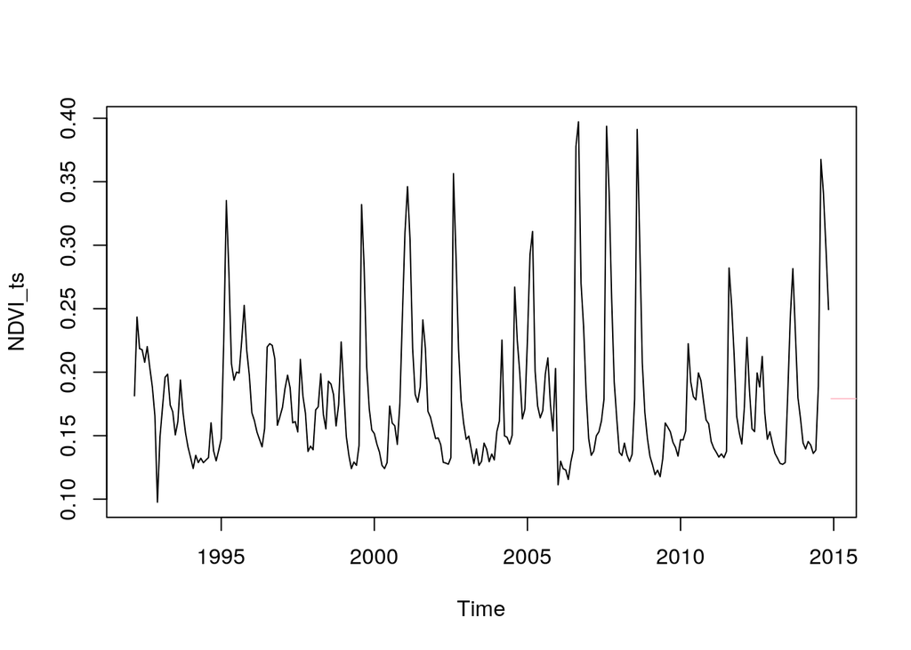

```r
plot(NDVI_ts)
lines(avg_forecast$mean, col = 'pink')
```

- Better to use built-in plotting functions

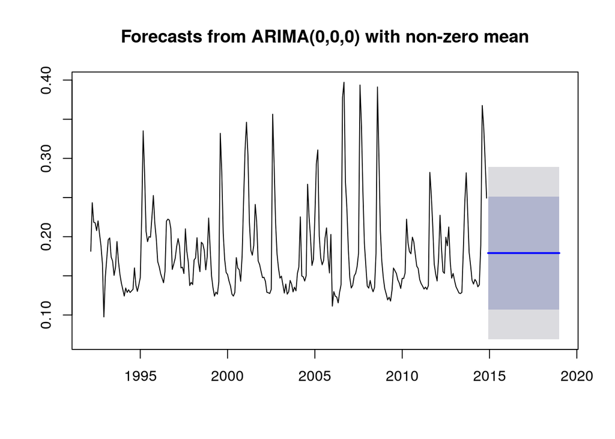

```r
plot(avg_forecast)
```

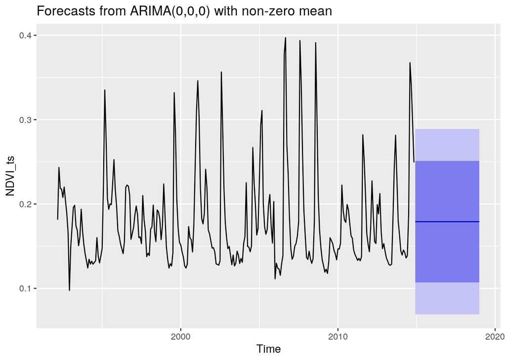

```r
autoplot(avg_forecast)
```

### Uncertainty

- Important to know how confident our forecast is
- Shaded areas provide this information
- Only variation in e_t is included, not errors in parameters
- By default 80% and 95%
- Can change using `level`

```r
avg_forecast
```

```
##          Point Forecast     Lo 80     Hi 80      Lo 95     Hi 95
## Dec 2014       0.179087 0.1071923 0.2509818 0.06913353 0.2890406
## Jan 2015       0.179087 0.1071923 0.2509818 0.06913353 0.2890406
## Feb 2015       0.179087 0.1071923 0.2509818 0.06913353 0.2890406
## Mar 2015       0.179087 0.1071923 0.2509818 0.06913353 0.2890406
## Apr 2015       0.179087 0.1071923 0.2509818 0.06913353 0.2890406
## May 2015       0.179087 0.1071923 0.2509818 0.06913353 0.2890406
## Jun 2015       0.179087 0.1071923 0.2509818 0.06913353 0.2890406
## Jul 2015       0.179087 0.1071923 0.2509818 0.06913353 0.2890406
## Aug 2015       0.179087 0.1071923 0.2509818 0.06913353 0.2890406
## Sep 2015       0.179087 0.1071923 0.2509818 0.06913353 0.2890406
## Oct 2015       0.179087 0.1071923 0.2509818 0.06913353 0.2890406
## Nov 2015       0.179087 0.1071923 0.2509818 0.06913353 0.2890406
## Dec 2015       0.179087 0.1071923 0.2509818 0.06913353 0.2890406
## Jan 2016       0.179087 0.1071923 0.2509818 0.06913353 0.2890406
## Feb 2016       0.179087 0.1071923 0.2509818 0.06913353 0.2890406
## Mar 2016       0.179087 0.1071923 0.2509818 0.06913353 0.2890406
## Apr 2016       0.179087 0.1071923 0.2509818 0.06913353 0.2890406
## May 2016       0.179087 0.1071923 0.2509818 0.06913353 0.2890406
## Jun 2016       0.179087 0.1071923 0.2509818 0.06913353 0.2890406
## Jul 2016       0.179087 0.1071923 0.2509818 0.06913353 0.2890406
## Aug 2016       0.179087 0.1071923 0.2509818 0.06913353 0.2890406
## Sep 2016       0.179087 0.1071923 0.2509818 0.06913353 0.2890406
## Oct 2016       0.179087 0.1071923 0.2509818 0.06913353 0.2890406
## Nov 2016       0.179087 0.1071923 0.2509818 0.06913353 0.2890406
## Dec 2016       0.179087 0.1071923 0.2509818 0.06913353 0.2890406
## Jan 2017       0.179087 0.1071923 0.2509818 0.06913353 0.2890406
## Feb 2017       0.179087 0.1071923 0.2509818 0.06913353 0.2890406
## Mar 2017       0.179087 0.1071923 0.2509818 0.06913353 0.2890406
## Apr 2017       0.179087 0.1071923 0.2509818 0.06913353 0.2890406
## May 2017       0.179087 0.1071923 0.2509818 0.06913353 0.2890406
## Jun 2017       0.179087 0.1071923 0.2509818 0.06913353 0.2890406
## Jul 2017       0.179087 0.1071923 0.2509818 0.06913353 0.2890406
## Aug 2017       0.179087 0.1071923 0.2509818 0.06913353 0.2890406
## Sep 2017       0.179087 0.1071923 0.2509818 0.06913353 0.2890406
## Oct 2017       0.179087 0.1071923 0.2509818 0.06913353 0.2890406
## Nov 2017       0.179087 0.1071923 0.2509818 0.06913353 0.2890406
## Dec 2017       0.179087 0.1071923 0.2509818 0.06913353 0.2890406
## Jan 2018       0.179087 0.1071923 0.2509818 0.06913353 0.2890406
## Feb 2018       0.179087 0.1071923 0.2509818 0.06913353 0.2890406
## Mar 2018       0.179087 0.1071923 0.2509818 0.06913353 0.2890406
## Apr 2018       0.179087 0.1071923 0.2509818 0.06913353 0.2890406
## May 2018       0.179087 0.1071923 0.2509818 0.06913353 0.2890406
## Jun 2018       0.179087 0.1071923 0.2509818 0.06913353 0.2890406
## Jul 2018       0.179087 0.1071923 0.2509818 0.06913353 0.2890406
## Aug 2018       0.179087 0.1071923 0.2509818 0.06913353 0.2890406
## Sep 2018       0.179087 0.1071923 0.2509818 0.06913353 0.2890406
## Oct 2018       0.179087 0.1071923 0.2509818 0.06913353 0.2890406
## Nov 2018       0.179087 0.1071923 0.2509818 0.06913353 0.2890406
## Dec 2018       0.179087 0.1071923 0.2509818 0.06913353 0.2890406
## Jan 2019       0.179087 0.1071923 0.2509818 0.06913353 0.2890406
```

```r
avg_forecast <- forecast(avg_model, level = c(50, 95))
avg_forecast
```

```
##          Point Forecast     Lo 50     Hi 50      Lo 95     Hi 95
## Dec 2014       0.179087 0.1412483 0.2169258 0.06913353 0.2890406
## Jan 2015       0.179087 0.1412483 0.2169258 0.06913353 0.2890406
## Feb 2015       0.179087 0.1412483 0.2169258 0.06913353 0.2890406
## Mar 2015       0.179087 0.1412483 0.2169258 0.06913353 0.2890406
## Apr 2015       0.179087 0.1412483 0.2169258 0.06913353 0.2890406
## May 2015       0.179087 0.1412483 0.2169258 0.06913353 0.2890406
## Jun 2015       0.179087 0.1412483 0.2169258 0.06913353 0.2890406
## Jul 2015       0.179087 0.1412483 0.2169258 0.06913353 0.2890406
## Aug 2015       0.179087 0.1412483 0.2169258 0.06913353 0.2890406
## Sep 2015       0.179087 0.1412483 0.2169258 0.06913353 0.2890406
## Oct 2015       0.179087 0.1412483 0.2169258 0.06913353 0.2890406
## Nov 2015       0.179087 0.1412483 0.2169258 0.06913353 0.2890406
## Dec 2015       0.179087 0.1412483 0.2169258 0.06913353 0.2890406
## Jan 2016       0.179087 0.1412483 0.2169258 0.06913353 0.2890406
## Feb 2016       0.179087 0.1412483 0.2169258 0.06913353 0.2890406
## Mar 2016       0.179087 0.1412483 0.2169258 0.06913353 0.2890406
## Apr 2016       0.179087 0.1412483 0.2169258 0.06913353 0.2890406
## May 2016       0.179087 0.1412483 0.2169258 0.06913353 0.2890406
## Jun 2016       0.179087 0.1412483 0.2169258 0.06913353 0.2890406
## Jul 2016       0.179087 0.1412483 0.2169258 0.06913353 0.2890406
## Aug 2016       0.179087 0.1412483 0.2169258 0.06913353 0.2890406
## Sep 2016       0.179087 0.1412483 0.2169258 0.06913353 0.2890406
## Oct 2016       0.179087 0.1412483 0.2169258 0.06913353 0.2890406
## Nov 2016       0.179087 0.1412483 0.2169258 0.06913353 0.2890406
```

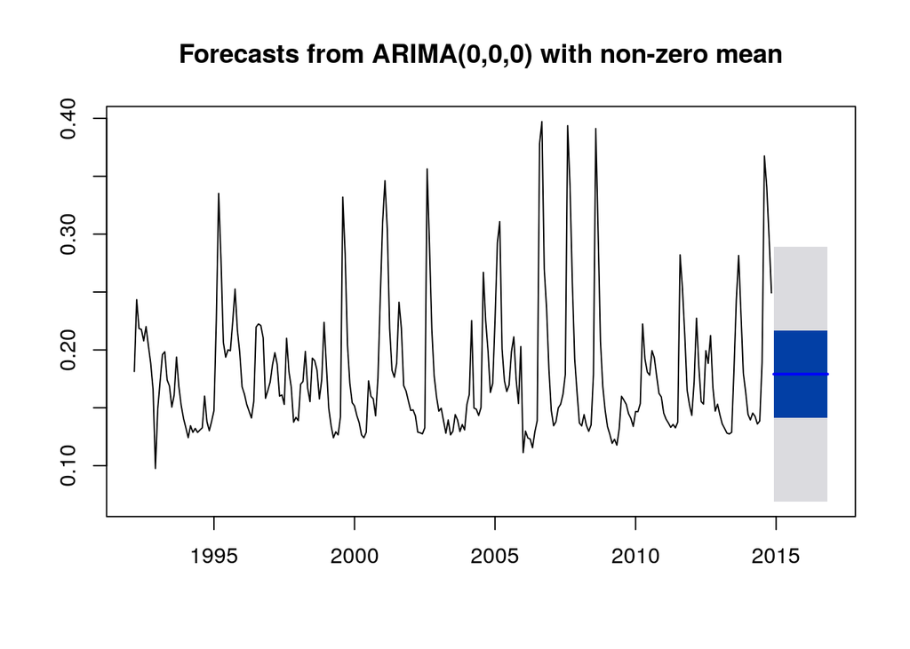

```r
plot(avg_forecast)
```

- Does it look like 95% of the empirical points fall within the gray band?
- How do we tell?
- We’ll come back to this when we learn how to evaluate forecasts

## Forecasting with more complex models

- Non-seasonal ARIMA
- `y_t = c + b1 * y_t-1 + b2 * y_t-2 + e_t`

> Instructors note: Actually `y_t = (1 - b1 - b2) * c + b1 * y_t-1 + b2 * y_t-2 + e_t` due to non-zero mean

> Have students build a non-seasonal ARIMA model: 36 month horizon, 80 and 99% prediction intervals Then discuss.

### How this forcast works

```r
arima_model = auto.arima(NDVI_ts, seasonal = FALSE)
arima_model
```

```
## Series: NDVI_ts
## ARIMA(2,0,0) with non-zero mean
##
## Coefficients:
##          ar1      ar2    mean
##       0.8612  -0.3123  0.1790
## s.e.  0.0575   0.0580  0.0054
##
## sigma^2 estimated as 0.001624:  log likelihood=490.43
## AIC=-972.87   AICc=-972.72   BIC=-958.43
```

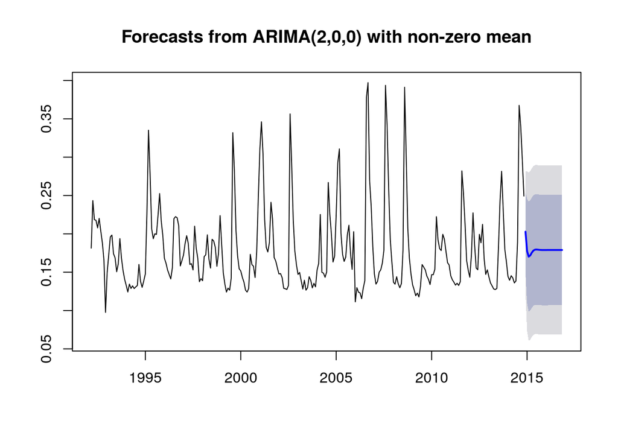

```r
arima_forecast = forecast(arima_model)
plot(arima_forecast)
```

- Forecast one step into the future
- Use the forecast value as `y_t-1` to forecast second step
- Can see the model at work
- First step influenced strongly postively by previous time-step which is high so above mean
- Second step is pulled below negative AR2 parameter
- Gradually reverts to the mean

### Seasonal ARIMA

- Best model we found last time
- Not much better than non-seasonal when looking at fit to data

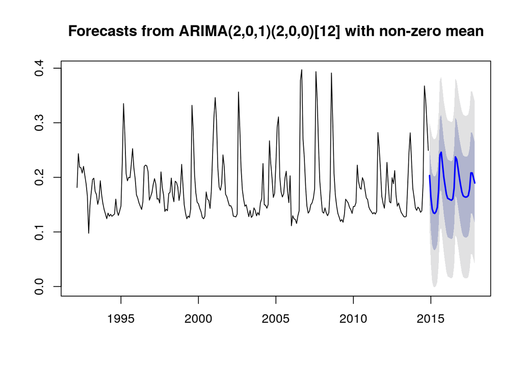

```r
seasonal_arima_model = auto.arima(NDVI_ts)
seasonal_arima_forecast = forecast(seasonal_arima_model, h = 36, level = c(80, 99))
plot(seasonal_arima_forecast)
```

* Do you think it might be a better model for forecasting? * We’ll find out how to tell next week.

# Forecasts from cross-sectional approach

- Just predictor variables, not time-series component
- Predict NDVI based on rain data
- Southern Arizona’s vegetation relies on summer monsoons, so focus on that precip

```r
library(dplyr)
library(lubridate)
data$date = as.Date(data$date, "%m/%d/%Y")
monsoon_data <- data %>%
  mutate(month = month(date), year = year(date)) %>%
  filter(month %in% c(7, 8, 9)) %>%
  group_by(year) %>%
  summarize(monsoon_rain = sum(rain), monsoon_ndvi = mean(NDVI))
```

- Visualize the relationship

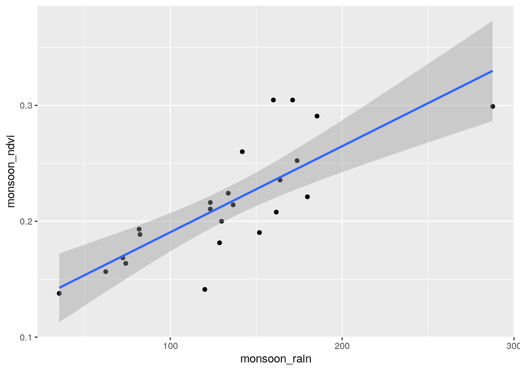

```r
ggplot(monsoon_data, aes(x = monsoon_rain, y = monsoon_ndvi)) +
  geom_point() +
  geom_smooth(method = "lm")
```

- Fit a linear model

```r
rain_model = lm('monsoon_ndvi ~ monsoon_rain', data = monsoon_data)
```

- Make a forecast using that model
- Requires forecast values for precipition

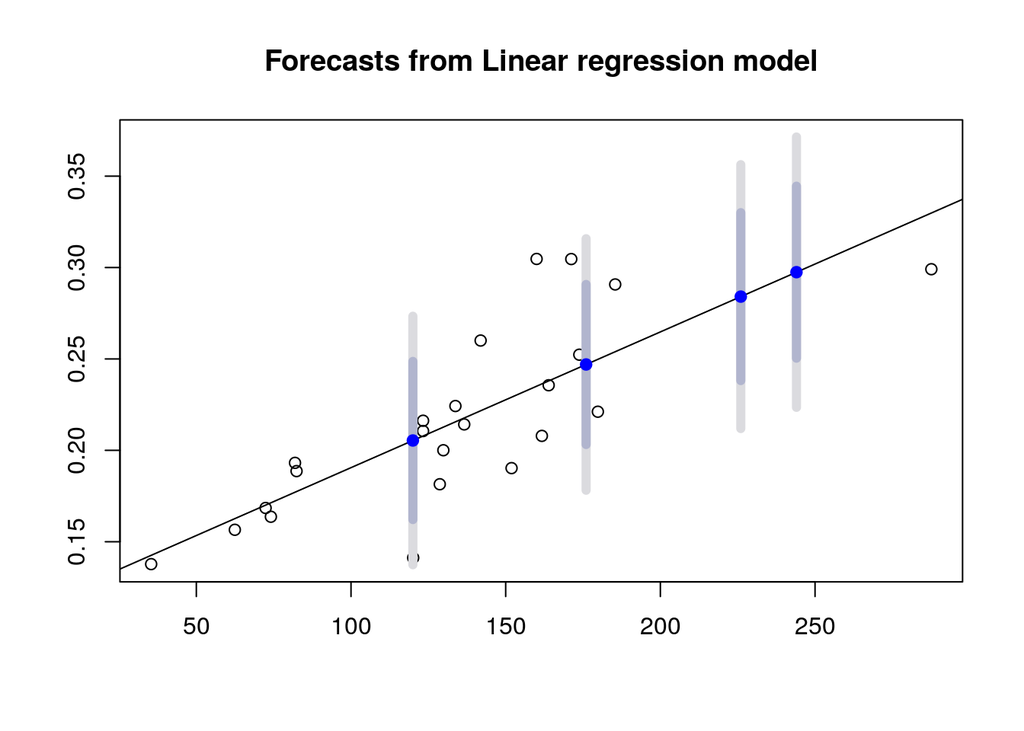

```r
rain_forecast = forecast(rain_model, newdata = data.frame(monsoon_rain = c(120, 226, 176, 244)))
plot(rain_forecast)
```